# Spatial Units of Analysis in Crime Location Choice Studies: A Systematic Scoping Review of Nearly Five Orders of Magnitude Variation

Research Team

2025-07-11

# 1 Abstract

**Background:** How researchers choose spatial units affects everything we understand about crime patterns and what interventions might work. But no one has systematically looked at how researchers actually make these decisions. We examine what spatial units researchers use in crime location choice studies - how big they are, whether they’ve changed over time, if they differ across countries, and what drives these choices.

**Methods:** We conducted a systematic review following PRISMA-ScR guidelines. We searched four databases and found 2,325 papers. After removing duplicates and irrelevant studies, we reviewed 80 papers and included 49 studies that met our criteria. Our final dataset of 49 studies and 51 observations (one study used 3 countries) represents the most comprehensive analysis of spatial unit selection in crime location choice research to date.

# 2 Introduction

Crime clusters in specific places, and researchers use spatial choice models to understand how offenders select these locations. These models treat crime location selection as a rational choice process where offenders evaluate potential locations based on costs and benefits. But there’s a fundamental decision that affects all crime location studies that gets little attention: choosing the spatial unit of analysis.

The spatial unit defines the geographical scale for modeling crime location decisions. Researchers might look at individual properties, street segments, neighborhoods, or administrative districts. This choice affects statistical power, how we interpret results, and what policies make sense. Despite this importance, the crime location choice literature lacks systematic guidelines for this decision.

## 2.1 Research Objectives

Given the absence of systematic evidence on spatial unit practices in crime location choice research, we address seven research questions:

**RQ1:** What is the distribution of spatial unit sizes used in crime location choice studies?

**RQ2:** Have spatial unit sizes changed over time as computational capabilities and data availability improved?

**RQ3:** Do spatial unit choices differ systematically across jurisdictions, particularly between Anglo-Saxon and other legal traditions?

**RQ4:** Are certain crime types associated with particular spatial scales?

**RQ5:** How does total study area size influence spatial unit selection?

**RQ6:** Do methodological approaches correlate with spatial unit selection?

**RQ7:** Does the number or type of explanatory variables relate to spatial unit choice?

# 3 Methods

## 3.1 Study Design and Registration

We conducted a systematic scoping review following the Preferred Reporting Items for Systematic Reviews and Meta-Analyses Extension for Scoping Reviews (PRISMA-ScR) guidelines. The review protocol was developed based on established frameworks for conducting systematic scoping reviews. No protocol was pre-registered due to the exploratory nature of the research questions.

Table 1. Naive Search Strategy and Results by Database

| Database | Records |
| --- | --- |
| Web of Science | 97 |
| Scopus | 105 |
| ProQuest | 47 |

Table 2. Optimized Search Strategy and Results by Database

| Database | Records |
| --- | --- |
| Web of Science | 681 |
| Scopus | 1,169 |
| ProQuest | 189 |
| Google Scholar | 286 |

# 4 Results

## 4.1 Study Selection and Data Overview

Our systematic search found 2,325 research papers from four databases. After removing duplicates and irrelevant studies, we reviewed 80 papers and included 49 studies that met our criteria.

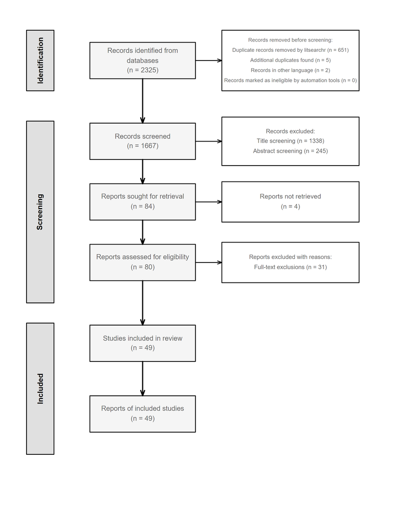

Figure 1. PRISMA 2020 flow diagram

## 4.2 Spatial Unit Size Distribution (RQ1)

Crime location choice studies vary enormously in spatial scale - 4.8 orders of magnitude from 136 m² individual properties to 8.48 km² administrative districts.

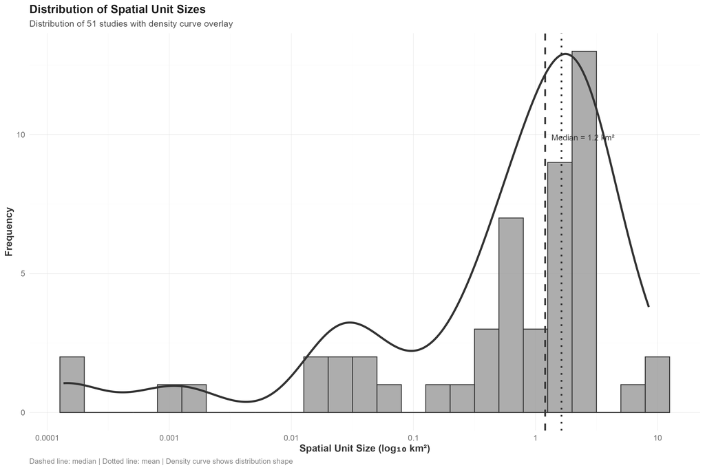

Figure 2. Distribution of spatial unit sizes

Table 3. Summary statistics

| Statistic | Value |
| --- | --- |
| Studies analyzed | 51 |
| Median unit size | 1.2 km² |
| Mean unit size | 1.63 km² |
| Smallest unit | 0.000136 km² |
| Largest unit | 8.48 km² |
| Standard deviation | 1.91 km² |
| Skewness (original) | 2.05 |
| Orders of magnitude | 4.8 |

## 4.3 Temporal Trends (RQ2)

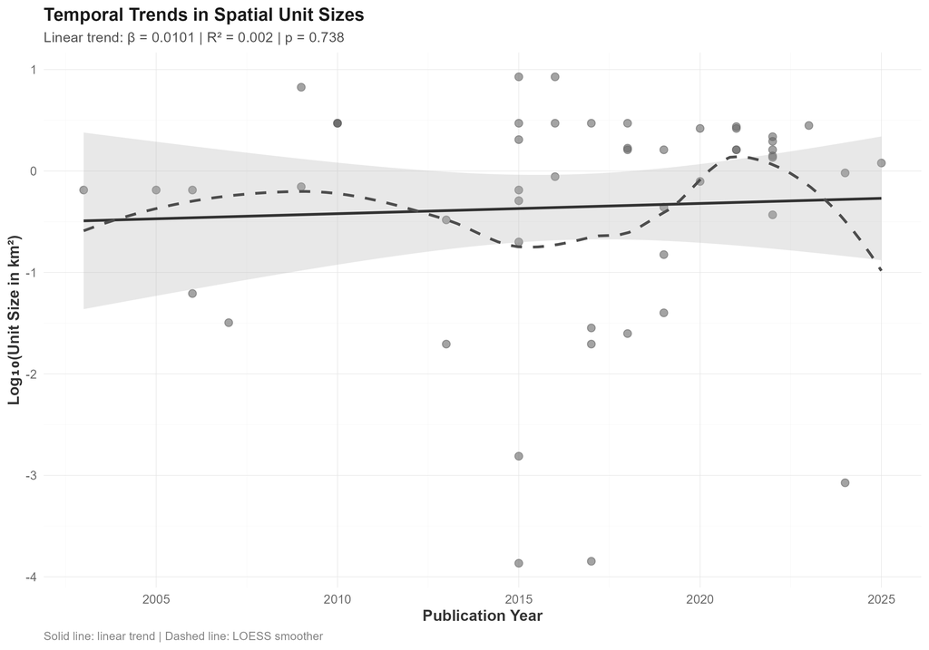

Figure 3. Temporal trends

Table 4. Model results

[output not shown]

# 5 Discussion

## 5.1 Conclusions

# 6 References

References would appear here in the final document.